# Lin et al.: AAV Microglia

Correlation between Transgene and Marker Gene (Extended Data Figure 8)

Ruiyu Ray Wang

2022-06-25

## TL;DR

You may click on the following links to fast forward to the codes directly producing the Figures:

- Extended Data Figure 8a
- Extended Data Figure 8b
- Extended Data Figure 8c
- Extended Data Figure 8d

Back to [index page](https://ruiyuraywang.github.io/Lin_AAV_Microglia_public/index.html).

## About this Vignette

One of the key questions asked by the reviewers is whether the transduction level (as measured by mScarlet expression mScarlet) is associated with activation of microglia, i.e. relationship between mScarlet level and signature gene. To address this point, we use the Smart-seq2 dataset to make violin plots of signature genes across groups, with overlaying jitter points colored by mScarlet levels.

## Initialization

```r
suppressPackageStartupMessages({
  library(Seurat)
  library(SeuratDisk)
  library(tidyverse)
  library(ggplot2)
  library(ggpubr)
  library(patchwork)
  library(RColorBrewer)
})
```

```r
querydata <- LoadH5Seurat('../data/AAV_MG_scRNAseq/query_clean.h5Seurat', verbose = F)
query_transferred <- LoadH5Seurat('../data/AAV_MG_scRNAseq/query_transferred.h5Seurat', verbose = F)
```

```r
queryaav_sub <- subset(querydata, subset = group == "AAV")
query_transduced <- subset(queryaav_sub, subset = transduction == "Transduced")
```

## Making Plots

### Extended Data Figure 8a

```r
features_hom = c("P2ry12","P2ry13","Cx3cr1","Csf1r","Lrp1","Ptpre","Lipa","Ets1")
features_hom_lab = c("Sall1", "Sirpa")

vplots <- list()
for(feature in features_hom){
  vplots[[feature]] <- FetchData(queryaav_sub, vars = c("treatment", "transduction", feature, "mScarlet_norm")) %>%
    ggplot(aes_string(x = "treatment", y = feature)) +
    geom_jitter(aes_string(color = "mScarlet_norm"), size = 1.5, alpha = 1, width = 0.20) +
    geom_violin(aes_string(fill = "treatment"), alpha = 0.3, width = 0.6) +
    scale_color_distiller('normalized\nmScarlet\nexpression', palette = "Reds", direction = 1) +
    scale_fill_manual(values = brewer.pal(n = 12, name = "Paired")[c(11,7)]) +
    guides(fill = "none") +
    theme_pubr() +
    theme(
      axis.title.x = element_blank(),
      axis.text.x = element_blank(),
      axis.title.y = element_text(size = 15, family = "Arial"),
      axis.text.y = element_text(size = 12, family = "Arial"),
      legend.position = "none",
      legend.title = element_text(size = 10, family = "Arial"),
      legend.text = element_text(size = 9, family = "Arial")
    )
}

for(feature in features_hom_lab){
  vplots[[feature]] <- FetchData(queryaav_sub, vars = c("treatment", "transduction", feature, "mScarlet_norm")) %>%
    ggplot(aes_string(x = "treatment", y = feature)) +
    geom_jitter(aes_string(color = "mScarlet_norm"), size = 1.5, alpha = 1, width = 0.20) +
    geom_violin(aes_string(fill = "treatment"), alpha = 0.3, width = 0.6) +
    scale_color_distiller('normalized\nmScarlet\nexpression', palette = "Reds", direction = 1) +
    scale_fill_manual(values = brewer.pal(n = 12, name = "Paired")[c(11,7)]) +
    guides(fill = "none") +
    theme_pubr() +
    theme(
      axis.title.x = element_blank(),
      axis.text.x = element_text(size = 12, family = "Arial"),
      axis.title.y = element_text(size = 15, family = "Arial"),
      axis.text.y = element_text(size = 12, family = "Arial"),
      legend.position = "none",
      legend.title = element_text(size = 10, family = "Arial"),
      legend.text = element_text(size = 9, family = "Arial"),
    )
}
```

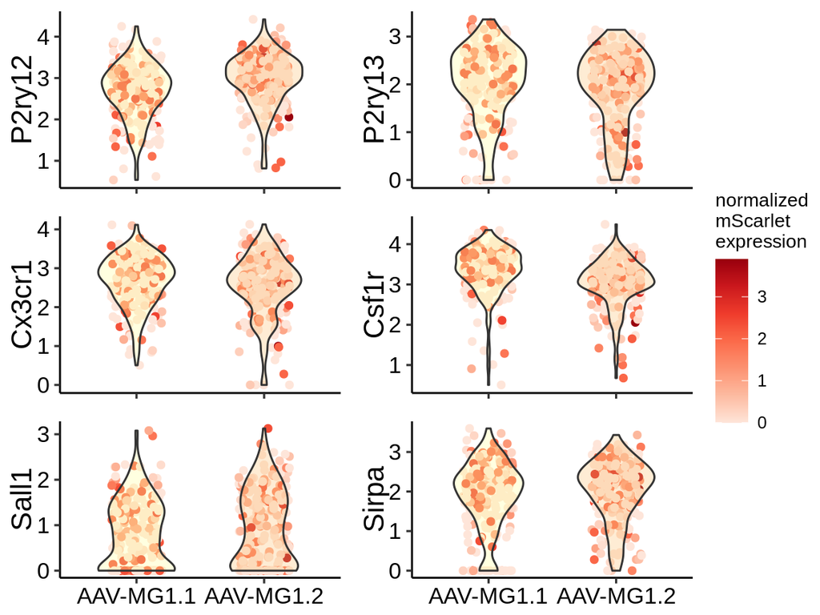

```r
ggarrange(vplots[["P2ry12"]], vplots[["P2ry13"]], vplots[["Cx3cr1"]], vplots[["Csf1r"]], vplots[["Sall1"]], vplots[["Sirpa"]],
          ncol=2, nrow=3, common.legend = TRUE, legend="right")
```

#### Extended Data Figure 8b

Alternatively, we could calculate the Spearmann correlation between the expression levels of signature genes and mScarlet transgene. We did not find a correlative relationship between the signature genes and transgene, suggesting that AAV transduction does not induce microglia activation. These are not required by the reviewers but I think they do better at illustrating the points.

```r
scplot <- list()
for(feature in c(features_hom, features_hom_lab)){
  scplot[[feature]] <- FetchData(query_transduced, vars = c(feature, "mScarlet_norm")) %>%
    ggscatter(
      x = "mScarlet_norm",
      y = feature,
      xlab = "Normalized mScarlet expression",
      add = c("reg.line"),
      add.params = list(color = "blue", linetype = "dashed"),
      size = .8
    ) +
    stat_cor(
      label.x.npc = 0.70,
      label.y.npc = 0.8,
      label.sep = "\n",
      color = "blue",
      cor.coef.name = "rho",
      method = "spearman",
      size = 2
    ) +
    theme(
      axis.title.x = element_text(size = 9),
      axis.text.x = element_text(size = 12),
      axis.title.y = element_text(size = 15),
      axis.text.y = element_text(size = 12),
    )
}
```

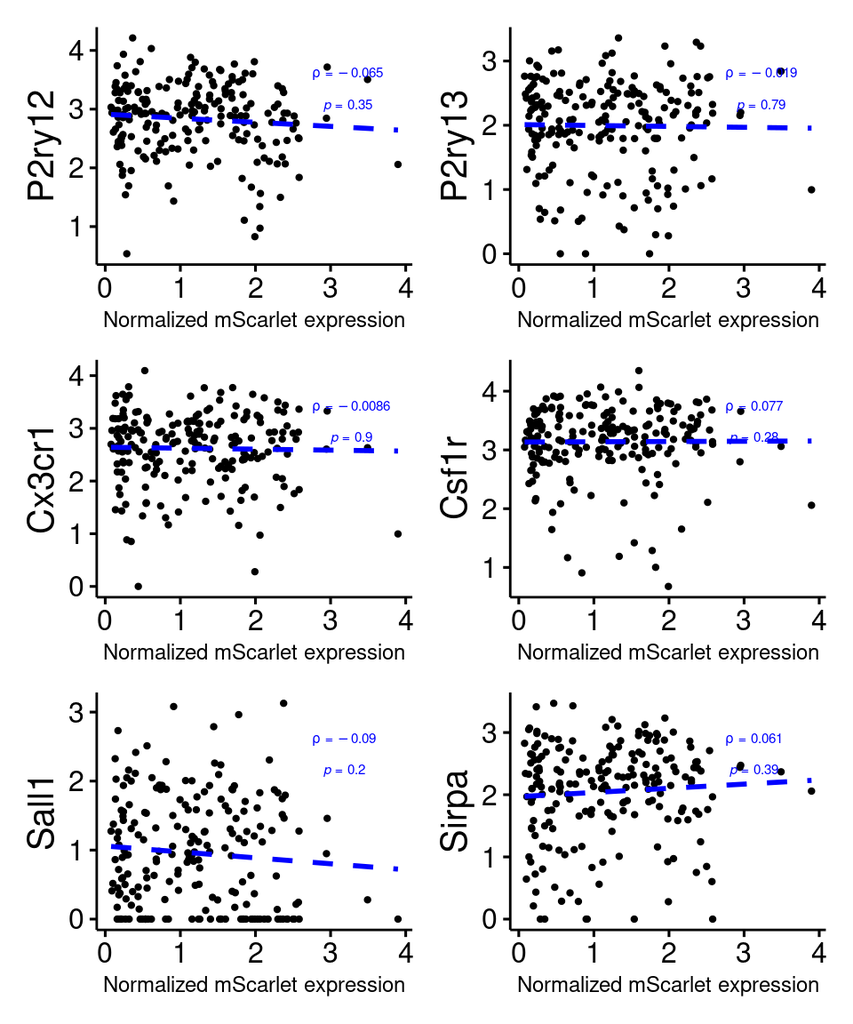

```r
(scplot[["P2ry12"]] | scplot[["P2ry13"]]) / (scplot[["Cx3cr1"]] | scplot[["Csf1r"]]) / (scplot[["Sall1"]] | scplot[["Sirpa"]])
```

#### Extended Data Figure 8c

```r
features_rea = c("Stat3","Gbp7","Ptgds","Irf7","Irf9","Saa3","Tlr2","Mt1","Mt2","Cd74","Lcn2","Tnf","Il1b","Cst7","Cxcl10",
                 "Ifitm3","Spp1")
features_rea_lab = c("Ccl5","Ccl2")

vplots <- list()
for(feature in features_rea){
  vplots[[feature]] <- FetchData(queryaav_sub, vars = c("treatment", "transduction", feature, "mScarlet_norm")) %>%
    ggplot(aes_string(x = "treatment", y = feature)) +
    geom_jitter(aes_string(color = "mScarlet_norm"), size = 1.5, alpha = 1, width = 0.20) +
    geom_violin(aes_string(fill = "treatment"), alpha = 0.3, width = 0.6) +
    scale_color_distiller('normalized\nmScarlet\nexpression', palette = "Reds", direction = 1) +
    scale_fill_manual(values = brewer.pal(n = 12, name = "Paired")[c(11,7)]) +
    guides(fill = "none") +
    theme_pubr() +
    theme(
      axis.title.x = element_blank(),
      axis.text.x = element_blank(),
      axis.title.y = element_text(size = 15, family = "Arial"),
      axis.text.y = element_text(size = 12, family = "Arial"),
      legend.position = "none",
      legend.title = element_text(size = 10, family = "Arial"),
      legend.text = element_text(size = 9, family = "Arial")
    )
}

for(feature in features_rea_lab){
  vplots[[feature]] <- FetchData(queryaav_sub, vars = c("treatment", "transduction", feature, "mScarlet_norm")) %>%
    ggplot(aes_string(x = "treatment", y = feature)) +
    geom_jitter(aes_string(color = "mScarlet_norm"), size = 1.5, alpha = 1, width = 0.20) +
    geom_violin(aes_string(fill = "treatment"), alpha = 0.3, width = 0.6) +
    scale_color_distiller('normalized\nmScarlet\nexpression', palette = "Reds", direction = 1) +
    scale_fill_manual(values = brewer.pal(n = 12, name = "Paired")[c(11,7)]) +
    guides(fill = "none") +
    theme_pubr() +
    theme(
      axis.title.x = element_blank(),
      axis.text.x = element_text(size = 12, family = "Arial"),
      axis.title.y = element_text(size = 15, family = "Arial"),
      axis.text.y = element_text(size = 12, family = "Arial"),
      legend.position = "none",
      legend.title = element_text(size = 10, family = "Arial"),
      legend.text = element_text(size = 9, family = "Arial"),
    )
}
```

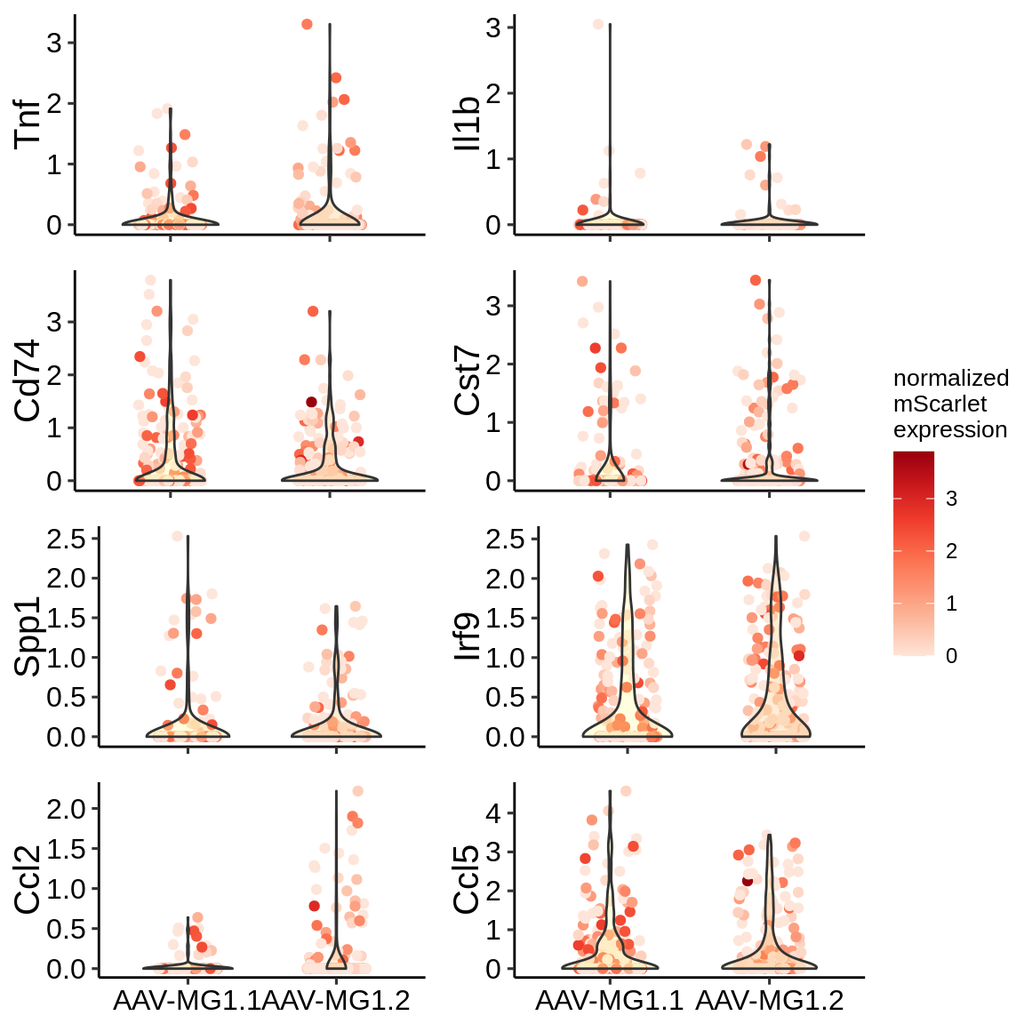

```r
ggarrange(vplots[["Tnf"]], vplots[["Il1b"]], vplots[["Cd74"]], vplots[["Cst7"]], vplots[["Spp1"]], vplots[["Irf9"]], vplots[["Ccl2"]], vplots[["Ccl5"]],
          ncol=2, nrow=4, common.legend = TRUE, legend="right")
```

#### Extended Data Figure 8d

```r
scplot <- list()
for(feature in c(features_rea, features_rea_lab)){
  scplot[[feature]] <- FetchData(query_transduced, vars = c(feature, "mScarlet_norm")) %>%
    ggscatter(
      x = "mScarlet_norm",
      y = feature,
      xlab = "Normalized mScarlet expression",
      add = c("reg.line"),
      add.params = list(color = "blue", linetype = "dashed"),
      size = .8
    ) +
    stat_cor(
      label.x.npc = 0.70,
      label.y.npc = 0.8,
      label.sep = "\n",
      color = "blue",
      cor.coef.name = "rho",
      method = "spearman",
      size = 2
    ) +
    theme(
      axis.title.x = element_text(size = 9),
      axis.text.x = element_text(size = 12),
      axis.title.y = element_text(size = 15),
      axis.text.y = element_text(size = 12),
    )
}
```

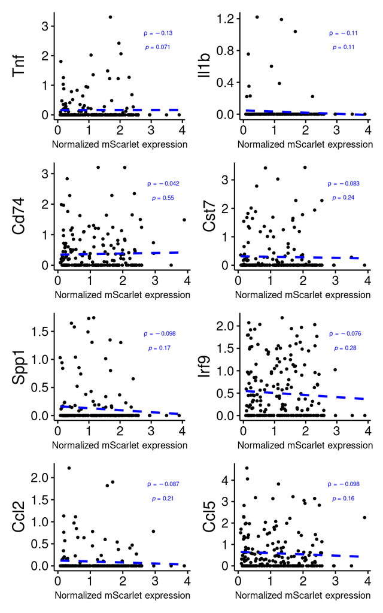

```r
(scplot[["Tnf"]] | scplot[["Il1b"]]) / (scplot[["Cd74"]] | scplot[["Cst7"]]) / (scplot[["Spp1"]] | scplot[["Irf9"]]) / (scplot[["Ccl2"]] | scplot[["Ccl5"]])
```